# En datadriven analys av "the Show About Nothing"

Seinfeld, ofta kallad "the Show About Nothing", är en av de mest ikoniska sitcoms i tv-historien. Men vad är det som verkligen gjorde Seinfeld till en succé? Genom att analysera data, om tittarsiffror, IMDb-betyg och manuskript från serien dyker vi ner i vilka faktorer som påverkade dess popularitet. I den här analysen undersöker vi vad siffrorna kan avslöja om serien.

## Data

För att analysera serien har jag samlat in data från flera källor som täcker olika aspekter av serien. Med web scraping från Wikipedia hämtade jag information om varje avsnitt, så som originalvisningsdatum, episodtitlar, säsongs- och avsnittsnummer, tittarsiffror med mera.

Från IMDb samlade jag in avsnittsbetyg, även detta genom web scraping, för att analysera sambandet mellan betyg och andra faktorer.

Jag använde också ett dataset med manusskript som innehåller nästan alla repliker från serien. Detta gjorde det möjligt att analysera vem som håller låda och hur den kan ha påverkat avsnittens betyg.

Slutligen kompletterades datan med sändningstider från Classic TV, där jag manuellt lade till NBC:s originalsändningstider i databasen för att få en bättre överblick över seriens sändningshistorik.

## En överblick av datan

Här nedan visas en sammanställning av den insamlade datan om episoderna:

[figure not shown]

## Tittarsiffror och deras förändringar över tid

För att få en öveblick av serien framsteg så visar vi i figur 1 tittarsiffrarnora vid varje avsnitts premiär.

Som vi kan se i figuren finns det en allmänt ökande trend i tittarsiffrorna över tid. Det ser ut som att det finns två tydliga nivåer av tittarsiffror:

- Den första perioden, mellan 1989 och 1993, med något lägre tittarsiffror.
- Den andra perioden, mellan 1993 och 1998, med betydligt högre tittarsiffror.

Det är inte förvånande att de två sista avsnitten av Seinfeld lockade en otroligt stor publik. Finalen den 14 maj 1998 hade nästan 76 miljoner tittare, en av de högsta siffrorna för en sitcom-final någonsin. Detta fenomen blev till och med ett ämne för sketchprogram som *Saturday Night Live*, där de skämtade om hur gatorna stod tomma och brottsligheten sjönk eftersom "alla" satt hemma och tittade på Seinfelds avslutning.

Men något som är svårare att förklara på rak arm är varför det skedde en sån drastisk ökning av tittarsiffror i början av 1993. Vi dyker djupare in i detta i nästa avsnitt!

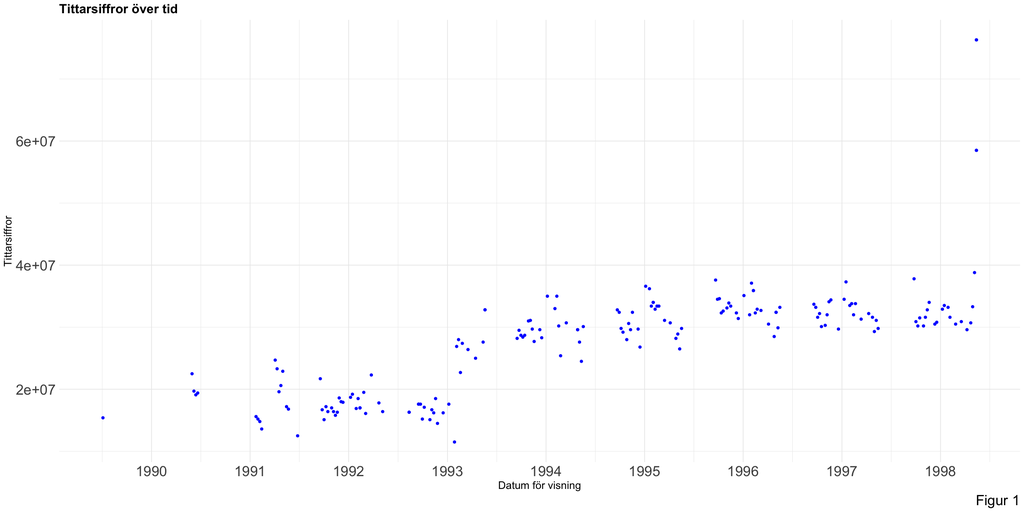

För att förtydliga detta fenomen presenterar vi en ytterligare visualisering, se figur 2, som tydligare illustrerar:

1. Seriens enorma framgång under finalen.
2. Den oväntade uppgången i tittarsiffror mitt i säsong 4.

Vid en jämförelse med de övriga säsongerna framträder dessa två aspekter som betydligt mer avvikande.

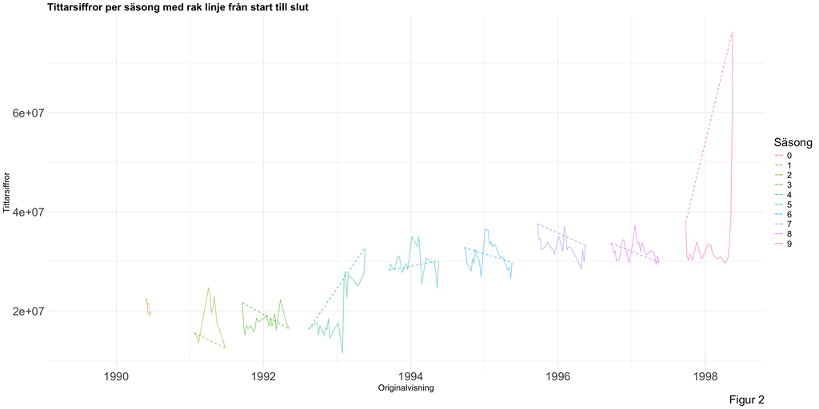

## The Cheers-Effect

När vi undersöker Seinfelds framgång kan de vara viktigt att även ta hänsyn till externa faktorer också. Två betydande aspekter är sändningsdagarna och sändningstiderna, som kan ha påverkat både tittarsiffror och seriens popularitet:

1. **Veckodagar:** Hur veckodagen påverkar tittarsiffror?
2. **Sändningstider:** Kan olika tider bidrog till förändringar i publikens beteende och programmets framgång?

### Variation av Veckodag

En möjlig förklaring till den drastiska ökningar av tittarsiffror i säsong 4 är förändringen av sändningsdagar. Under seriens gång testades olika veckodagar för att sända Seinfeld, vilket illustreras i figur 3. Här ser vi en solklar trend av ökning i tittarsiffrorna för avsnitt som sändes på Torsdagar jämfört med de som sändes på Onsdagar. Även om man fick en sämre(senare) sändningstid, se figur 4, så fick serien en dragningskraft av den poluära serien Cheers som hade sändningstid kl 21:00 på Torsdagar.

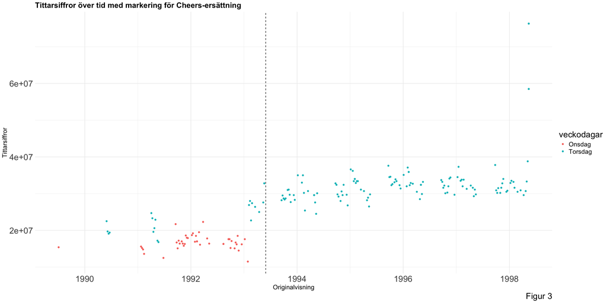

#### Variation av Sändningstid

NBC har som sagt varierat sändningstiderna för serien, ibland i samband med att man bytte sändningsdag. I figuren nedan ser vi tittarsiffror kopplade till sändningstiderna. Man kan här igen se effekten av att sändas efter Cheers.

I figur 3 & 4 är en streckad linje markerad som visar det datum då Seindfeld officiellt ersatte den ikoniska serien Cheers på NBC:s Torsdagskväll kl 21:00. Detta byte kan ha haft en signifikant inverkan på programmets ökande tittarsiffror och dess position som en av de mest populära sitcoms i historien.

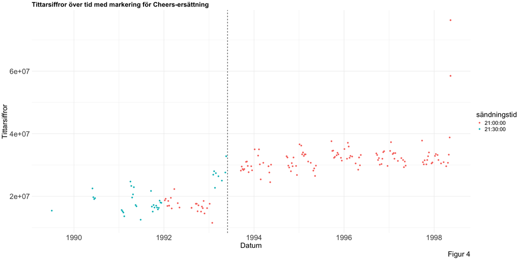

## Vem Håller Låda?

Med Jerry's ord andel menas: $$\text{Jerry's Andel av Ord i Avsnittet}=\frac{\text{Antal Ord Jerry säger i Avsnittet}}{\text{Totala Antal Ord som sägs i Avsnittet}}.$$

Som vi kan se, till vänster i figuren, har Jerrys andel av dialogen i avsnitten minskat genom åren. Detta har gett utrymme för andra karaktärer att ta större plats.

I de tidiga säsongerna, särskilt säsong 1, var Jerrys andel betydligt högre. Detta kan delvis förklaras av hans långa monologer, hämtade direkt från hans standup-rutiner, som ofta användes i början av avsnitten. Detta format gjorde att han dominerande dialogandel under seriens första år.

I den högra delen av figuren, som visar förhållandet mellan Jerrys dialogandel och avsnittens betyg, framträder ett intressant mönster: avsnitt med höga betyg tenderar att ha en lägre dialogandel för Jerry. Om detta är pga Jerry's frånvaro, eller andra karaktärers närvaro lämnar jag till egen spekulation.

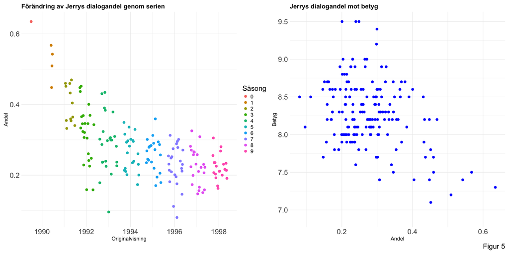

## Högst & Lägst betygsatta avsnitt

Nedanför, i figur 6, ser vi en analys av dialogfördelningen i de fem lägst betygsatta och de fem högst betygsatta avsnitten. Den övre raden representerar de lägst betygsatta avsnitten, medan den nedre raden visar de högst betygsatta.

Som vi också kunde observera i figur 5, har Jerry en signifikant större andel av replikerna i de "sämsta" avsnitten. Detta indikerar att avsnitt där dialogen är starkt centrerad kring Jerry tenderar att få lägre betyg.

I kontrast, i de högst betygsatta avsnitten i raden under, ser vi en mer jämn fördelning av repliker mellan karaktärerna. Det verkar som om en större balans i dialogen influerar till avsnittens framgång. Dessutom verkar inkluderingen av biroller spela en viss roll i att höja betyget på dessa avsnitt.

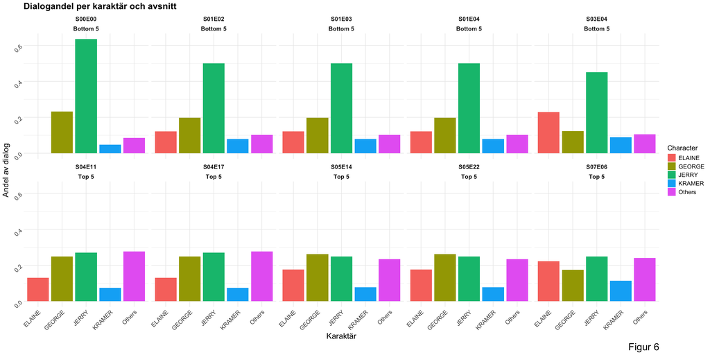

Seinfelds framgång är ett resultat av smart manusförfattande, en balans mellan karaktärerna och rätt timing i sändningsschemat. Genom att kombinera dessa element blev "the Show About Nothing" en tidlös klassiker som är fortsatt omtyckt!